# Wikidata Ontology vs Wikipedia Categories

Emma Leonhart, Evan Pasenau, Jordyn Campen

Data snapshot: 2026-04-05 23:11 UTC — 23 items — 5 domains — 23/23 with P910 categories

Download PDF version | [View source on GitHub](https://github.com/EmmaLeonhart/301-project)

## Introduction

This report compares Wikidata's P31 (instance of) ontological classification with English Wikipedia's category system across multiple domains. Rather than relying on string matching, we use Wikidata's own **P910 (topic's main category)** property to follow the semantic link from a P31 class to its corresponding Wikipedia category.

### Methodology

1. Retrieve the item's **P31 (instance of)** classes from Wikidata
2. For each P31 class, follow **P910 (topic's main category)** to get the Wikidata item representing the Wikipedia category
3. Use the **enwiki sitelink** on that category item to get the actual Wikipedia category name
4. Fetch the item's Wikipedia categories and check for membership
5. If not found directly, walk up the Wikipedia parent-category hierarchy to measure depth

## Domain Summary

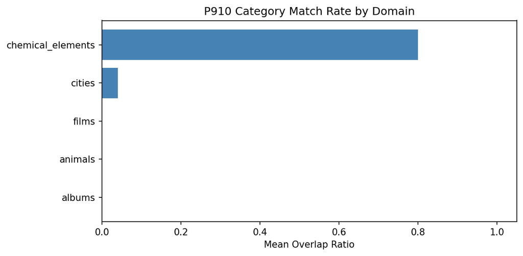

## P910 Category Coverage

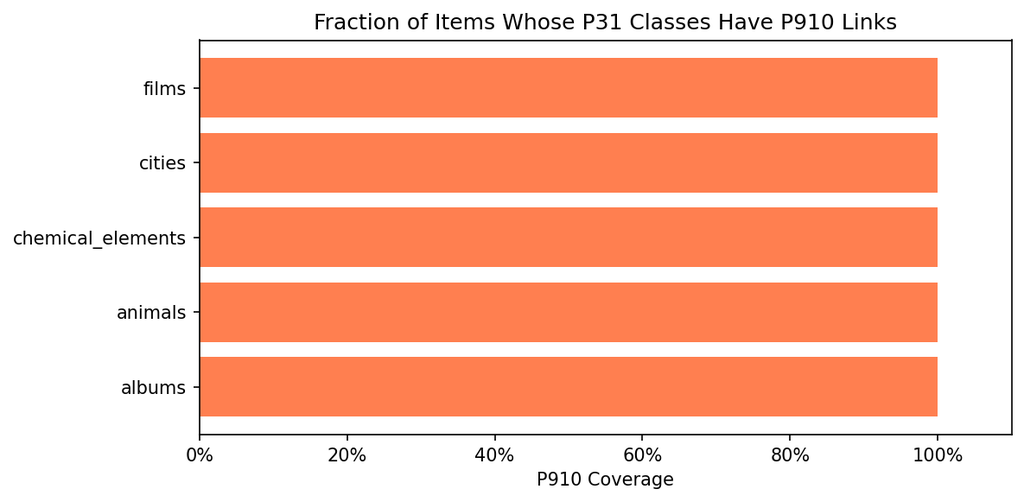

## P31 Count vs Category Count

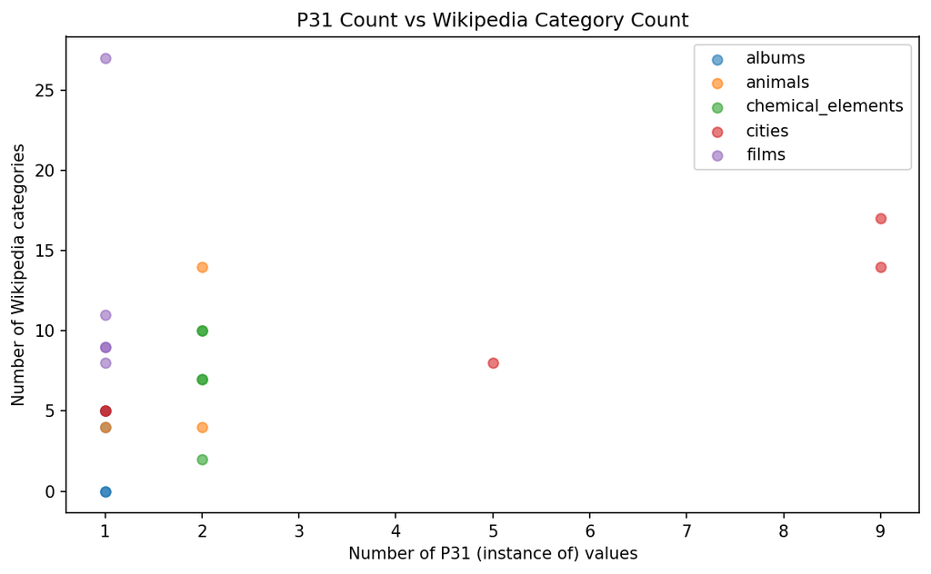

## Overlap Distribution

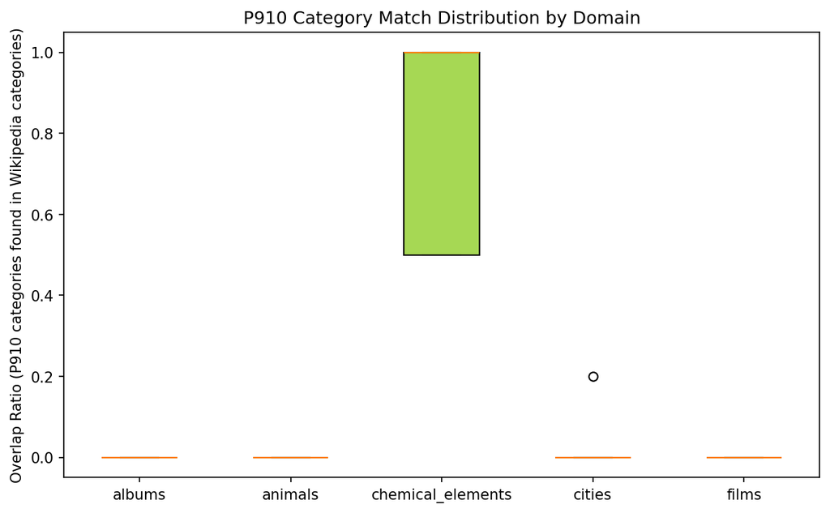

## Category Depth

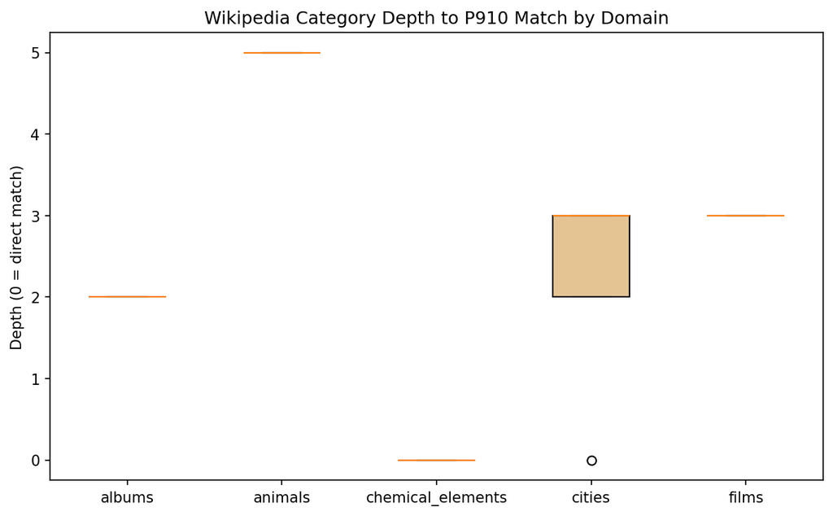

## P910 Match Rate

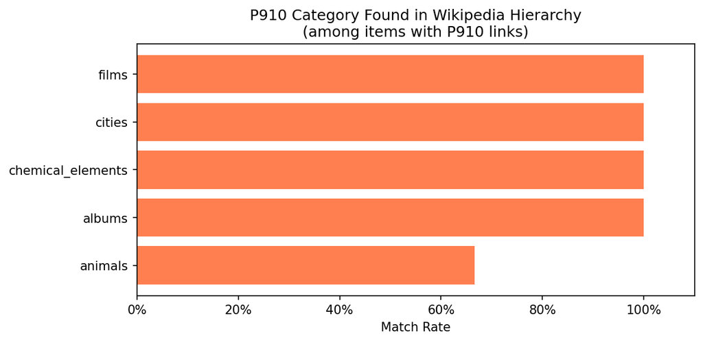

## Findings

By following Wikidata's own P910 (topic's main category) links rather than heuristic string matching, we measure real semantic alignment between the two systems.

## Ethics and Limitations

- **Cultural bias**: Only English Wikipedia is analyzed.
- **P910 coverage**: Limited to P31 classes that have P910 properties.
- **API rate limits**: Fixed delays limit sample size per pipeline run.
- **Snapshot in time**: Results reflect data at acquisition time.
- **Category hierarchy ceiling**: Parent-category traversal is capped at 5 levels.